# Mapping with Geopandas

## Better Looking Maps

A few problems with the maps presented above are the fontface, and the grid (graticule if it were latitude and longitude). If you are more familiar with ArcMap, when you create a map, you have a lot of options in terms of styling your map. You also can do a lot with matplotlib, but it requires getting here hands dirty in the code. Let's clean up the map a little bit by setting some default values at the matplotlib level. We will import the whole library as mpl to begin.

```python
import matplotlib as mpl
```

Now we can change the default font family and size used for the map. This will help create a consistent style in your map text, but also is easier than changing individually for each piece of text. This won't work if you want different font styles, but a map will typically only use one, or two. I'll use Times New Roman, since it should be available on most computers.

```python
mpl.rc('font',family='Times New Roman')
mpl.rcParams.update({'font.size': 9})
```

Here we have set the default font family to Times New Roman, and a default size to 9. Replotting with these settings produces this map:

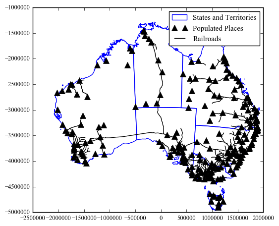

```python
fig, ax = plt.subplots(figsize=(6,6))
ax.set_aspect('equal')
admin.plot(ax=ax,facecolor='white',edgecolor='blue')
populated.plot(ax=ax,color='k',marker='^',markersize=8)
railroads.plot(ax=ax, color='k')
admin_patch = mpatches.Patch(facecolor='white', edgecolor='blue', label='States and Territories')
populated_line = mlines.Line2D([],[], color='k', marker='^', linestyle='', markersize=8, label="Populated Places")
railroads_line = mlines.Line2D([], [], color='k', marker='', linestyle='-',label="Railroads")
plt.legend(handles=[admin_patch,populated_line,railroads_line])
```

That certainly reduced the overlapping tick labels. Still, they aren't formatted very nicely. In matplotlib you have control over how these labels look. This can be setup using a custom function that processes the label and returns a string. It requires importing the ticker object.

```python
from matplotlib import ticker
```

First we will define the function using standard python notation. I'll call it meters_formatter, but you can call it whatever. It will accept to arguments x (the string to be formatted) and p (the position of the ticker).

The function processes the number so that it is formatted with commas at appropriate intervals, and appends an m afterwards. It then returns the result.

```
def meters_formatter(x, p):
    strRes = '{:,}m'.format(int(x))
    return strRes
```

Then we need to get access to the formatter for the major ticks. This is the ticks on the axes that contains a label. We do this twice, once for each axis. It can use the same function. We pass the name of the function we created into the `ticker.FuncFormatter` method.

```
ax.xaxis().set_major_formatter(ticker.FuncFormatter(meters_formatter))
ax.yaxis().set_major_formatter(ticker.FuncFormatter(meters_formatter))
```

It's all a bit confusing, I realize, but this is a flexible way to modify the tick labels like 500000 so they look more like 500,000m. And you don't need to do this manually for each piece of label, but all at once using the generic function. Let's see the results here.

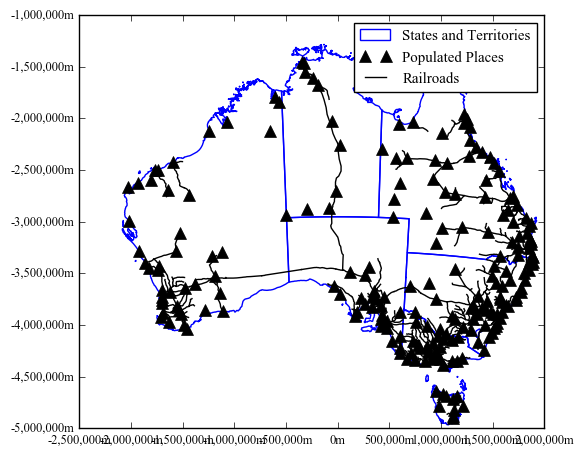

```python
def meters_formatter(x, p):
    strRes = '{:,}m'.format(int(x))
    return strRes

fig, ax = plt.subplots(figsize=(6,6))
ax.set_aspect('equal')
admin.plot(ax=ax,facecolor='white',edgecolor='blue')
populated.plot(ax=ax,color='k',marker='^',markersize=8)
railroads.plot(ax=ax, color='k')

ax.xaxis.set_major_formatter(ticker.FuncFormatter(meters_formatter))
ax.yaxis.set_major_formatter(ticker.FuncFormatter(meters_formatter))

admin_patch = mpatches.Patch(facecolor='white', edgecolor='blue', label='States and Territories')
populated_line = mlines.Line2D([],[], color='k', marker='^', linestyle='', markersize=8, label="Populated Places")
railroads_line = mlines.Line2D([], [], color='k', marker='', linestyle='-',label="Railroads")
plt.legend(handles=[admin_patch,populated_line,railroads_line])
```

Now we are back to the problem of overlapping labels along the axes. We can fix this by specifying the interval between major and minor ticks. Or just major ticks in this case. We could do this manually, given we can see the bounds of the plot window and provide a list of numbers. Even better is to let matplotlib figure it out for us using `ticker.MultipleLocator` According to the documentation this fucntion performs this task: Set a tick on every integer that is multiple of base in the view interval. In other words, it finds the interval based on the value you pass. We set the intervals for the major ticks using the `axis.set_major_locator()`. In the above figure we can see that the interval is already at 500,000, so we need to go bigger Setting it to one million works well.

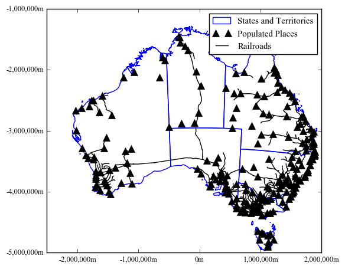

```python
def meters_formatter(x, p):
    strRes = '{:,}m'.format(int(x))
    return strRes

fig, ax = plt.subplots(figsize=(6,6))
ax.set_aspect('equal')
admin.plot(ax=ax,facecolor='white',edgecolor='blue')
populated.plot(ax=ax,color='k',marker='^',markersize=8)
railroads.plot(ax=ax, color='k')

ax.xaxis.set_major_formatter(ticker.FuncFormatter(meters_formatter))
ax.yaxis.set_major_formatter(ticker.FuncFormatter(meters_formatter))

ax.xaxis.set_major_locator(ticker.MultipleLocator(1000000))
ax.yaxis.set_major_locator(ticker.MultipleLocator(1000000))

admin_patch = mpatches.Patch(facecolor='white', edgecolor='blue', label='States and Territories')
populated_line = mlines.Line2D([],[], color='k', marker='^', linestyle='', markersize=8, label="Populated Places")
railroads_line = mlines.Line2D([], [], color='k', marker='', linestyle='-',label="Railroads")
plt.legend(handles=[admin_patch,populated_line,railroads_line])
```

## North Arrow and Scale Bar

One of the advantages of using a grid, is it provides you with scale and direction of your map. At least, if you are familiar with the coordinate system. It certainly provides the scale of your map

```python
from matplotlib.path import Path
```

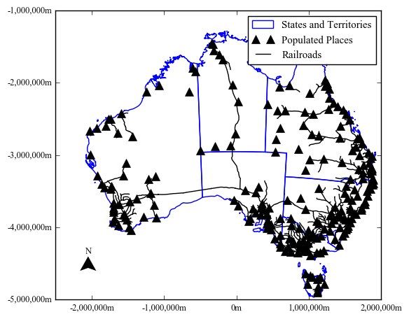

```python
def northArrowPatch(x,y,width,height,ax,trans):
    """x - lower left corner of arrow in trans coordinates
       y - lower left corner of arrow in trans coordiantes
       width - estimated width of arrow in trans coordiantes
       height - estimated height of arrow in trans coordiantes
       ax - axes to add patch and text
       trans - transformation the coordinates are in"""
    verts = []
    codes = []
    for part in range(0,4):
        if part == 0:
            verts.append((x,y))
            codes.append(Path.MOVETO)
        if part == 1:
            verts.append((x+(width/2.0),y-(height)))
            codes.append(Path.LINETO)
        if part == 2:
            verts.append((x,y-(height-(1.0/5.0)*height)))
            codes.append(Path.LINETO)
        if part == 3:
            verts.append((x-(width/2.0),y-(height)))
            codes.append(Path.LINETO)
            verts.append((x,y))
            codes.append(Path.CLOSEPOLY)

    path = Path(verts, codes)
    northPatch = mpatches.PathPatch(path, facecolor='k', lw=0,transform=trans)
    ax.add_patch(northPatch)
    lbl = ax.text(x,y+((1.0/5.0)*height),'N',transform=trans,ha='center')
    return northPatch,lbl

def meters_formatter(x, p):
    strRes = '{:,}m'.format(int(x))
    return strRes

fig, ax = plt.subplots(figsize=(6,6))
ax.set_aspect('equal')
admin.plot(ax=ax,facecolor='white',edgecolor='blue')
populated.plot(ax=ax,color='k',marker='^',markersize=8)
railroads.plot(ax=ax, color='k')

ax.xaxis.set_major_formatter(ticker.FuncFormatter(meters_formatter))
ax.yaxis.set_major_formatter(ticker.FuncFormatter(meters_formatter))

ax.xaxis.set_major_locator(ticker.MultipleLocator(1000000))
ax.yaxis.set_major_locator(ticker.MultipleLocator(1000000))

nrth,lbl = northArrowPatch(.1,.15,.05,.05,ax,ax.transAxes)
admin_patch = mpatches.Patch(facecolor='white', edgecolor='blue', label='States and Territories')
populated_line = mlines.Line2D([],[], color='k', marker='^', linestyle='', markersize=8, label="Populated Places")
railroads_line = mlines.Line2D([], [], color='k', marker='', linestyle='-',label="Railroads")
plt.legend(handles=[admin_patch,populated_line,railroads_line])
```

```python
def scaleBar(x,y,mapdistance,ax,trans,subdivisions=1,height=.01):
    """x - lower left corner of arrow in trans coordinates
       y - lower left corner of arrow in trans coordiantes
       mapdistance - maximum distance to show on the scalebar
       ax - axes to add patch and text
       trans - transformation the coordinates are in
       subdivision - number of subdivisions to show in the scalebar
       height - height of the bar part of the scalebar"""
    #ymin, ymax = ax.get_ylim() #returns bottom,top
    xmin, xmax = ax.get_xlim() #returns left,right
    abs_width = abs(xmax-xmin)
    length = 1.0/abs_width * mapdistance
    ax.add_patch(mpatches.Rectangle((x,y),length, height, transform=trans,lw=0,facecolor='red'))
```

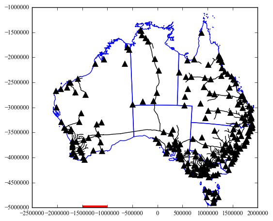

```python
fig, ax = plt.subplots(figsize=(6,6))
ax.set_aspect('equal')
admin.plot(ax=ax,facecolor='white',edgecolor='blue')
populated.plot(ax=ax,color='k',marker='^',markersize=8)
railroads.plot(ax=ax, color='k')

scaleBar(0.22222222222222221,.0,500000,ax,ax.transAxes)
#print ax.transAxes.inverted().transform(ax.transData.transform([-1500000,-5000000])) #use these functions if you want to see where a data coordinate lies on the axes
```

```python
def scaleBar(x,y,mapdistance,ax,trans,subdivision=1,height=.02):
    """x - lower left corner of arrow in trans coordinates
       y - lower left corner of arrow in trans coordiantes
       mapdistance - maximum distance to show on the scalebar
       ax - axes to add patch and text
       trans - transformation the coordinates are in
       subdivision - number of subdivisions to show in the scalebar
       height - height of the bar part of the scalebar"""
    xmin, xmax = ax.get_xlim() #returns left,right
    abs_width = abs(xmax-xmin)
    length = 1.0/abs_width * mapdistance
    if subdivision > 1.0:
        sublength = float(length)/subdivision
        fColor = 'black'
        subx = x
        for i in range(0,subdivision):

            ax.add_patch(mpatches.Rectangle((subx,y), sublength, height, transform=trans,facecolor=fColor,edgecolor='black',lw=.5))
            subx += sublength
            if fColor == 'black':
                fColor = 'white'
            else:
                fColor = 'black'

    else:
        ax.add_patch(mpatches.Rectangle((x,y), length, height, transform=trans,facecolor='black',edgecolor='black'))

    ax.text(x,y+height*1.5,'0',transform=trans,ha='center')
    ax.text(x+length,y+height*1.5,meters_formatter(mapdistance,None),transform=trans,ha='center')
```

[output not shown]

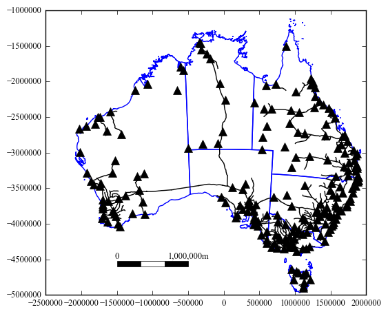

```python
fig, ax = plt.subplots(figsize=(6,6))
ax.set_aspect('equal')
admin.plot(ax=ax,facecolor='white',edgecolor='blue')
populated.plot(ax=ax,color='k',marker='^',markersize=8)
railroads.plot(ax=ax, color='k')

scaleBar(0.22222222222222221,.1,1000000,ax,ax.transAxes,subdivision=3)
```

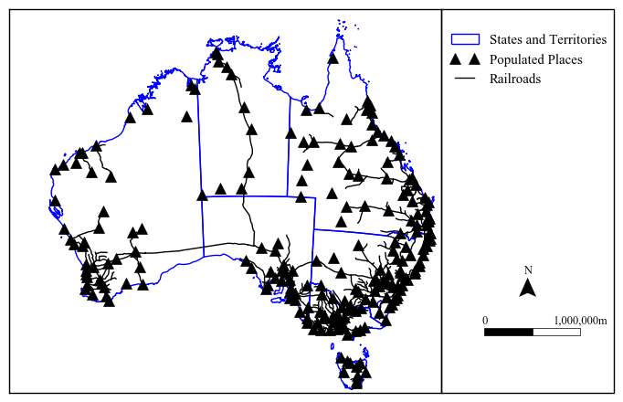

```python
from matplotlib.path import Path
import matplotlib as mpl
from matplotlib import ticker
import matplotlib.pyplot as plt
import geopandas as gpd
import matplotlib.patches as mpatches
import matplotlib.lines as mlines
%matplotlib inline

admin = gpd.read_file("Data/ne_10m_admin_1_states_provinces_aus.shp")
populated = gpd.read_file("Data/ne_10m_populated_places_simple_aus.shp")
railroads = gpd.read_file("Data/ne_10m_railroads_aus.shp")

def meters_formatter(x, p):
    strRes = '{:,}m'.format(int(x))
    return strRes

def scaleBar(x,y,mapdistance,ax,trans,subdivision=1,height=.02):
    """x - lower left corner of arrow in trans coordinates
       y - lower left corner of arrow in trans coordiantes
       mapdistance - maximum distance to show on the scalebar
       ax - axes to add patch and text
       trans - transformation the coordinates are in
       subdivision - number of subdivisions to show in the scalebar
       height - height of the bar part of the scalebar"""
    xmin, xmax = ax.get_xlim() #returns left,right
    abs_width = abs(xmax-xmin)
    length = 1.0/abs_width * mapdistance
    if subdivision > 1.0:
        sublength = float(length)/subdivision
        fColor = 'black'
        subx = x
        for i in range(0,subdivision):
            ax.add_patch(mpatches.Rectangle((subx,y), sublength, height, transform=trans,facecolor=fColor,edgecolor='black',lw=.5,clip_on=False))
            subx += sublength
            if fColor == 'black':
                fColor = 'white'
            else:
                fColor = 'black'

    else:
        ax.add_patch(mpatches.Rectangle((x,y), length, height, transform=trans,facecolor='black',edgecolor='black',clip_on=False))

    ax.text(x,y+height*1.5,'0',transform=trans,ha='center')
    ax.text(x+length,y+height*1.5,meters_formatter(mapdistance,None),transform=trans,ha='center')

def northArrowPatch(x,y,width,height,ax,trans):
    """x - lower left corner of arrow in trans coordinates
       y - lower left corner of arrow in trans coordiantes
       width - estimated width of arrow in trans coordiantes
       height - estimated height of arrow in trans coordiantes
       ax - axes to add patch and text
       trans - transformation the coordinates are in"""
    verts = []
    codes = []
    for part in range(0,4):
        if part == 0:
            verts.append((x,y))
            codes.append(Path.MOVETO)
        if part == 1:
            verts.append((x+(width/2.0),y-(height)))
            codes.append(Path.LINETO)
        if part == 2:
            verts.append((x,y-(height-(1.0/5.0)*height)))
            codes.append(Path.LINETO)
        if part == 3:
            verts.append((x-(width/2.0),y-(height)))
            codes.append(Path.LINETO)
            verts.append((x,y))
            codes.append(Path.CLOSEPOLY)

    path = Path(verts, codes)
    northPatch = mpatches.PathPatch(path, facecolor='k', lw=0,transform=trans,clip_on=False)
    ax.add_patch(northPatch)
    lbl = ax.text(x,y+((1.0/5.0)*height),'N',transform=trans,ha='center')
    return northPatch,lbl

mpl.rc('font',family='Times New Roman')
mpl.rcParams.update({'font.size': 9})

fig, ax = plt.subplots(figsize=(5,5))
ax.set_aspect('equal')

ax.get_xaxis().set_visible(False)
ax.get_yaxis().set_visible(False)

admin.plot(ax=ax,facecolor='white',edgecolor='blue')
populated.plot(ax=ax,color='k',marker='^',markersize=8)
railroads.plot(ax=ax, color='k')

ax.xaxis.set_major_formatter(ticker.FuncFormatter(meters_formatter))
ax.yaxis.set_major_formatter(ticker.FuncFormatter(meters_formatter))

ax.xaxis.set_major_locator(ticker.MultipleLocator(1000000))
ax.yaxis.set_major_locator(ticker.MultipleLocator(1000000))

#ucomment these lines to create a box around the north arrow and scalebar in the lower left hand corner of the map.
#ax.add_patch(mpatches.Rectangle((.02,.02), .4, .15, transform=ax.transAxes,facecolor='white',edgecolor='black'))
#nrth,lbl = northArrowPatch(.06,.1,.05,.05,ax,ax.transAxes)
#scaleBar(.12,.055,1000000,ax,ax.transAxes,subdivision=3)



#for the legend
admin_patch = mpatches.Patch(facecolor='white', edgecolor='blue', label='States and Territories')
populated_line = mlines.Line2D([],[], color='k', marker='^', linestyle='', markersize=8, label="Populated Places")
railroads_line = mlines.Line2D([], [], color='k', marker='', linestyle='-',label="Railroads")

#plt.legend(handles=[admin_patch,populated_line,railroads_line])#uncomment if you want the legend in the upper right

#place these in the legend at the bottom of the map
additionalArtists = []
brd = ax.add_patch(mpatches.Rectangle((1.0,0), .4, 1.0, transform=ax.transAxes,facecolor='white',edgecolor='black',clip_on=False))
additionalArtists.append(brd)
lgd = plt.legend(handles=[admin_patch,populated_line,railroads_line],bbox_to_anchor=(1.01, .95),loc=2,borderaxespad=0.,frameon=False)
additionalArtists.append(lgd)
nrth,lbl = northArrowPatch(1.2,.3,.04,.05,ax,ax.transAxes)

scaleBar(1.1,.15,1000000,ax,ax.transAxes,subdivision=2)
plt.tight_layout()

fig.savefig('mapOutput_fin.png', dpi=300, format='png', bbox_extra_artists=additionalArtists, bbox_inches='tight')
```

Note the addition of a new property `clip_on`. Setting this to false allows the patches to be drawn outside the axes areas. This let us create a legend on the side.

Finally we export the map to a png file with a dpi of 300. In order to make sure everything is exported to the file that is outside of our figure boundaries, we need to keep track of the artists we added like the legend object and the rectangle border that was added on the right-hand side. Create a variable to keep the artists as they are added, and append them to a list. This gets placed in the `savefig()` function.

[figure not shown]

Hopefully, it is obvious the intent of this chapter was not to give you a "cookbook" of different map styles, but to give you the intuition about how you need to create maps in matplotlib using geopandas as a base. You have nearly complete control over every aspect of your map, and it is up to you on how to use it. You could just use matplotlib as a way to draw the spatial data, then export this out to a graphic design program like Adobe Illustrator or the open source InkScape to have even better (visual) graphic design control.